# Homework 11 Assigned 10/13/16

**Created by Robin Cunningham, UNC Chapel Hill**

## Intro to Multiple Linear Regression

*GPA Data Set*

*We will use this exercise to compare the regression coefficients that we find by solving the Normal Equations (Slide 9 of Lecture 5) to the Output from using `lm` to find the regression coefficients.*

1. Get the data set “College GPA.csv” and put it in your working directory along with this document and the console of R-Studio. Note that all of the code boxes below are set to `eval=FALSE` so that your file will *knit* but you will need to change this to put out your answers.
1. Read in the GPA file and assign it to the handy name provided.Then go ahead and print it so you have it for reference.

   ```r
   #gpa <-
   gpa = read.csv("College GPA.csv")
   head(gpa)
   ```

   ```
   ##   First.Yr.GPA Math.SAT Verbal.SAT HS.Math.GPA HS.English.GPA
   ## 1         1.97      321        247        2.30           2.63
   ## 2         2.74      718        436        3.80           3.57
   ## 3         2.19      358        578        2.98           2.57
   ## 4         2.60      403        447        3.58           2.21
   ## 5         2.98      640        563        3.38           3.48
   ## 6         1.65      237        342        1.48           2.14
   ```

   ```r
   summary(gpa)
   ```

   ```
   ##   First.Yr.GPA      Math.SAT       Verbal.SAT     HS.Math.GPA
   ##  Min.   :1.650   Min.   :237.0   Min.   :247.0   Min.   :1.470
   ##  1st Qu.:2.007   1st Qu.:392.0   1st Qu.:362.0   1st Qu.:2.143
   ##  Median :2.615   Median :486.0   Median :459.5   Median :3.170
   ##  Mean   :2.593   Mean   :511.6   Mean   :478.2   Mean   :2.854
   ##  3rd Qu.:3.080   3rd Qu.:647.0   3rd Qu.:585.0   3rd Qu.:3.520
   ##  Max.   :3.900   Max.   :791.0   Max.   :704.0   Max.   :3.800
   ##  HS.English.GPA
   ##  Min.   :2.140
   ##  1st Qu.:2.623
   ##  Median :3.065
   ##  Mean   :3.010
   ##  3rd Qu.:3.465
   ##  Max.   :3.740
   ```

2. Create each of the Matrices, X, Y, and Beta_hat that you will need to solve the normal equations.
   $$X\hat{B} =Y$$
   Begin by defining variables
   $$Y = First year GPA$$
   $$X1 = Math SAT$$
   $$X2 = Verbal SAT$$
   $$X3 = HS Math GPA$$
   $$X4 = HS English GPA.$$
   Then initialize a Beta_hat vector of all zeros and the appropriate length.

   ```r
   n <- nrow(gpa)
   Y <- gpa$First.Yr.GPA
   X1 <- gpa$Math.SAT
   X2 <- gpa$Verbal.SAT
   X3 <- gpa$HS.Math.GPA
   X4 <- gpa$HS.English.GPA
   Beta_hat <- numeric(n)
   ```

3. We have our variables now, but they are all stored as vectors and we must convert them to matrices. Use `cbind` to create the matrix X. You will need to create a vector of 1’s of the appropriate length first. Also, use the `matrix` command to turn Y and Beta_hat into matrices with the correct dimensions. After you have made them, go ahead and print (with labels) all three Matrices for the normal equations with labels.

   ```r
     #Change Beta_hat to a matrix
   Beta_hat = matrix(Beta_hat)
     #Change Y to a matrix
   Y = matrix(Y)
     #create X
     # First create column of ones and convert Xi to columns
   X = c(rep(1, n))
     # make matrix X
   X = cbind(X, X1, X2, X3, X4, deparse.level = 0)
   ```

c. Calculate the least squares values of Beta_hat. In the calculation of the least squares values, I recommend calculating X^tX first, then the inverse, then Beta_hat.  
I went ahead and wrote the code to print out the Beta_i values after they are calculated.

```r
  #Calculate Beta_hat
  Beta_hat = solve(t(X)%*%X)%*%t(X)%*%Y

  #Print individual values of Beta_i
  labels = matrix(c("Beta_0", "Beta_1", "Beta_2", "Beta_3", "Beta_4"), nrow = 5)
  beta_summary <- cbind(labels, Beta_hat)
  beta_summary
```

```
##      [,1]     [,2]
## [1,] "Beta_0" "0.161549575051402"
## [2,] "Beta_1" "0.00201016759533022"
## [3,] "Beta_2" "0.00125219730826483"
## [4,] "Beta_3" "0.189440168465175"
## [5,] "Beta_4" "0.0875637413857484"
```

4. Now that you know how `lm` calculates these coefficients, it is ok to use `lm` directly to calculate the least-squares statistics. Do that here and assign the model to the name gpa.mlr. Then get the summary output of the model.

   ```r
   gpa.mlr = lm(Y ~ X1+X2+X3+X4)
   summary(gpa.mlr)
   ```

   ```
   ##
   ## Call:
   ## lm(formula = Y ~ X1 + X2 + X3 + X4)
   ##
   ## Residuals:
   ##      Min       1Q   Median       3Q      Max
   ## -0.44328 -0.12837  0.00257  0.13400  0.53900
   ##
   ## Coefficients:
   ##              Estimate Std. Error t value Pr(>|t|)
   ## (Intercept) 0.1615496  0.4375321   0.369  0.71712
   ## X1          0.0020102  0.0005844   3.439  0.00365 **
   ## X2          0.0012522  0.0005515   2.270  0.03835 *
   ## X3          0.1894402  0.0918680   2.062  0.05697 .
   ## X4          0.0875637  0.1764963   0.496  0.62700
   ## ---
   ## Signif. codes:  0 '***' 0.001 '**' 0.01 '*' 0.05 '.' 0.1 ' ' 1
   ##
   ## Residual standard error: 0.2685 on 15 degrees of freedom
   ## Multiple R-squared:  0.8528, Adjusted R-squared:  0.8135
   ## F-statistic: 21.72 on 4 and 15 DF,  p-value: 4.255e-06
   ```

5. How do your estimates of the parameters compare to R’s?(Comment box below)

```
They are exactly the same
```

6. Interpret each of the regression paramaters in words. That is, explain what each value means in terms of the scenario.

7. Find a 95% confidence interval for $\beta_4$.(Use either a code-box, a comment box, or both to hold your answer.)

```r
    confint(gpa.mlr)
```

```
##                     2.5 %      97.5 %
## (Intercept) -7.710279e-01 1.094127066
## X1           7.644598e-04 0.003255875
## X2           7.665843e-05 0.002427736
## X3          -6.371925e-03 0.385252262
## X4          -2.886292e-01 0.463756656
```

8. For a new individual with  
   MSAT = 640  
   VSAT = 540  
   HSM = 3.8  
   HSE = 3.2  
   What is your best estimate for their 1st-year gpa?  
   Please use R to give your answer.

```r
X1 = c(640)
X2 = c(540)
X3 = c(3.8)
X4 = c(3.2)
predict(gpa.mlr, data.frame(X1, X2, X3, X4))
```

```
##       1
## 3.12432
```

i. For the person described in Part (h), find a 95% confidence interval for their 1st-year gpa. (Note that s^2 is given in the R output of the linear model.)

```r
predict(gpa.mlr, data.frame(X1, X2, X3, X4), interval="confidence", level=0.95)
```

```
##       fit      lwr      upr
## 1 3.12432 2.928688 3.319952
```

j. We should have done this to start the regression analysis, but make plots of Y versus each of the predictors (4 plots) and discuss what you see. (Try to get everything into this RMarkdown document. No paper this time.)

[figure not shown]

```r
    X1 <- gpa$Math.SAT
    X2 <- gpa$Verbal.SAT
    X3 <- gpa$HS.Math.GPA
    X4 <- gpa$HS.English.GPA
    plot(Y, X1, main="Y vs Predictor", ylab="First Year GPA", xlab="Math SAT", col="blue")
```

[figure not shown]

```r
    plot(Y, X2, main="Y vs Predictor", ylab="First Year GPA", xlab="Verbal SAT", col="blue")
```

[figure not shown]

```r
    plot(Y, X3, main="Y vs Predictor", ylab="First Year GPA", xlab="HS Math GPA", col="blue")
```

[figure not shown]

```r
    plot(Y, X4, main="Y vs Predictor", ylab="First Year GPA", xlab="HS English GPA", col="blue")
```

k. Makes histograms of each of the variables to see if there are any obvious outliers or other odd behavior. Print the histograms and any comments.

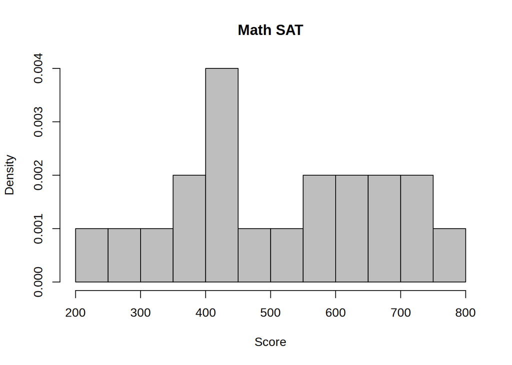

```r
hist(X1, breaks=10, main="Math SAT", xlab="Score", col="grey", freq=FALSE)
```

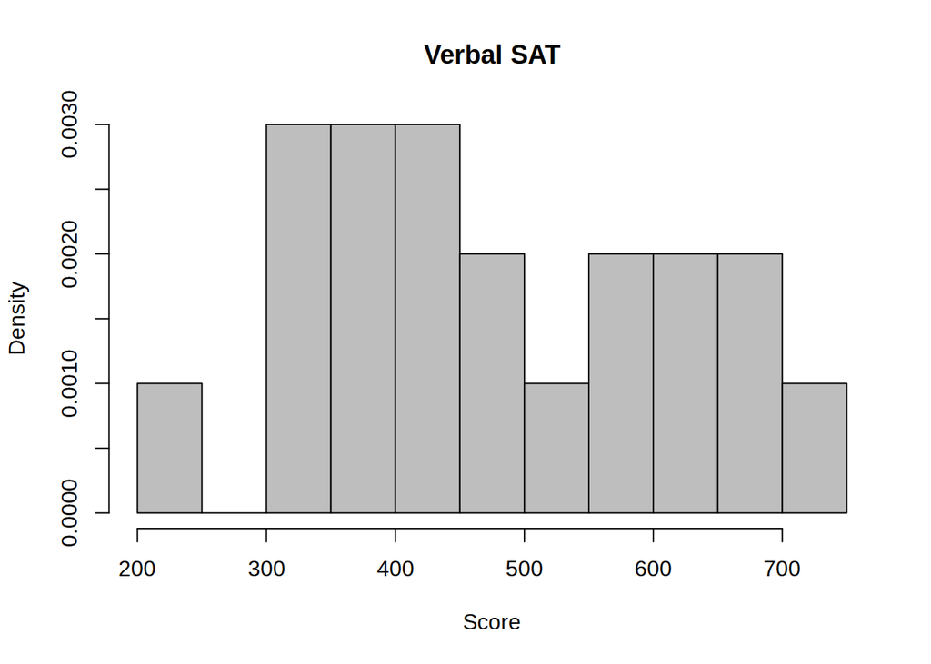

```r
hist(X2, breaks=10, main="Verbal SAT", xlab="Score", col="grey", freq=FALSE)
```

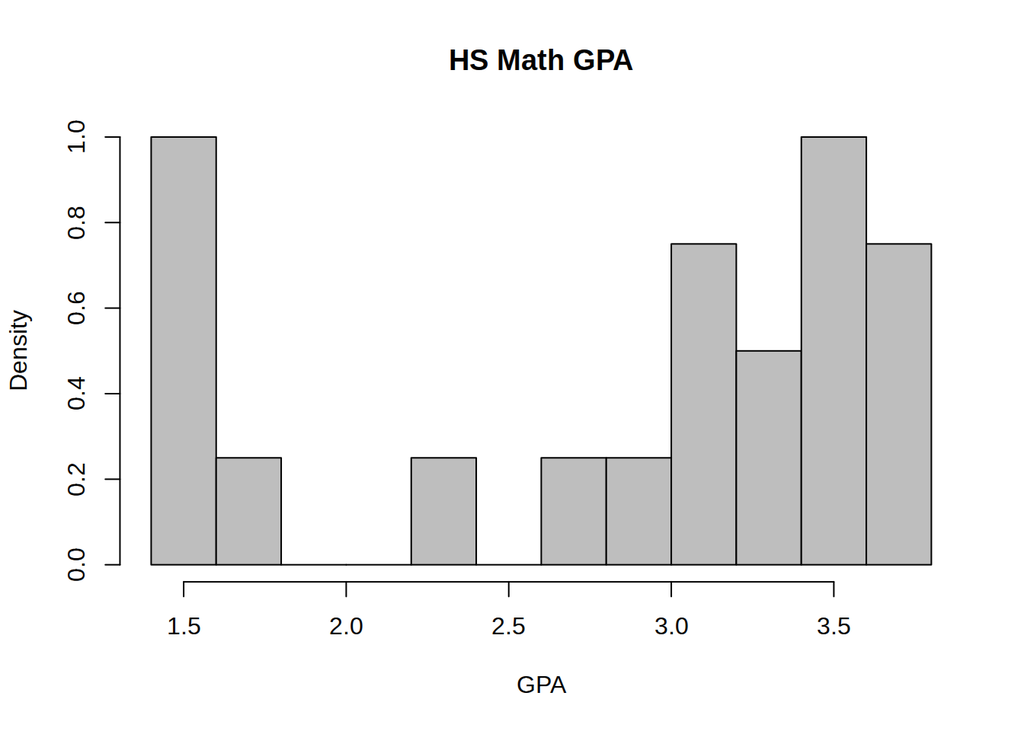

```r
hist(X3, breaks=10, main="HS Math GPA", xlab="GPA", col="grey", freq=FALSE)
```

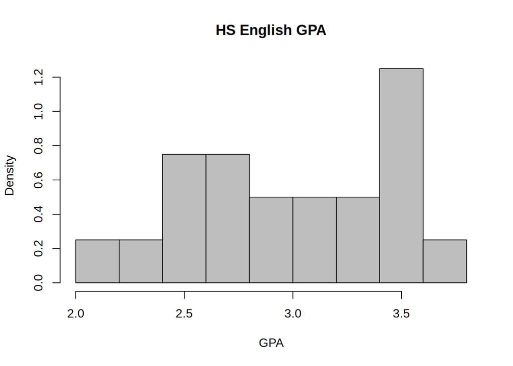

```r
hist(X4, breaks=10, main="HS English GPA", xlab="GPA", col="grey", freq=FALSE)
```

```r
# There are definite outliers in the HS Math GPA, it seems a disproportionately large amount of students got below a 1.75 GPA
```

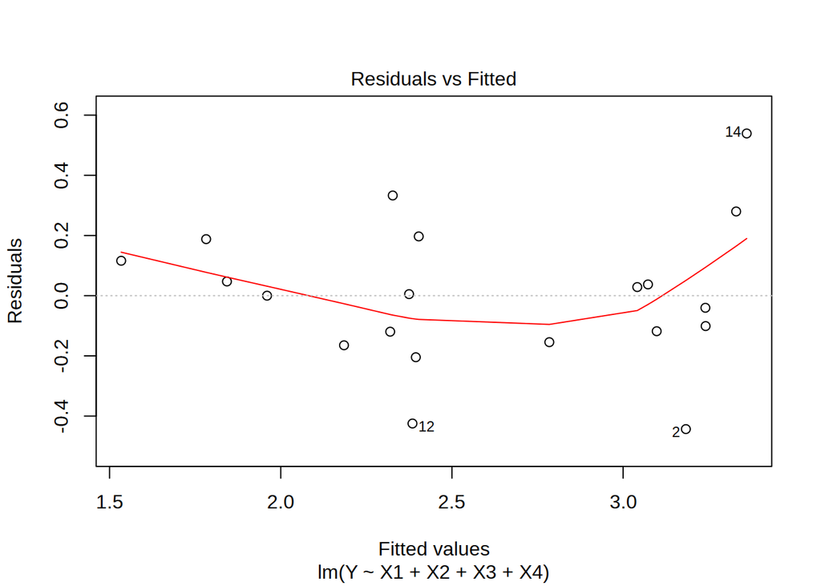

```r
plot(gpa.mlr, which=1)
```

13. Find a 95% prediction interval for the individual described in Part (h) above. It is ok to use R’s `predict` function for this. Interpret the result in terms of the scenario.